# *Dog invasions in Protected Areas, a case study using camera trapping, citizen science and artificial intelligence*

Santiago Gutiérrez-Zapata<sup>1*</sup>, Simone Santoro<sup>1</sup>, Manuel Emilio Gegúndez<sup>1</sup>, Nuria Selva<sup>2,3,4</sup>, Javier Calzada<sup>1,2</sup> <sup>1</sup> Departamento de Ciencias Integradas, Facultad de Ciencias Experimentales, Universidad de Huelva, Huelva, Spain. <sup>2</sup> Centro de Estudios Avanzados en Física, Matemáticas y Computación, Facultad de Ciencias Experimentales, Universidad de Huelva, Huelva, Spain. <sup>3</sup> Institute of Nature Conservation, Polish Academy of Sciences, al. Adama Mickiewicza 33, 31-120 Kraków, Poland. <sup>4</sup> Estación Biológica de Doñana, Consejo Superior de Investigaciones Científicas, Sevilla, Spain. *Corresponding Author: Santiago Gutierrez-Zapata (santiago.gutierrez@dci.uhu.es)

2024-05-22

## Required libraries

```r
library(DHARMa)
library(effects)
library(ggplot2)
library(AICcmodavg)
library(glmmTMB)
library(dplyr)
library(mgcv)
library(mgcViz)
library(DT)
library(activity)
library(kableExtra)
```

## General Dataset

The dataset comprises records of dogs’ events collected in Doñana National Park using camera traps deployed between October 2020 and January 2024. Additionally, sites where no dogs’ events occurred are included for statistical analyses. The different columns are described as follows:

- site: site ID.
- camera: camera ID.
- date_time: date and time of detections in dd/mm/yyyy H:M format
- presence: locations with dogs’ events (presence = “yes”), locations without dogs’ envents (presence = “no”)
- count: number of dogs present in each event
- collar: presence or absence of collars on the dogs
- dist_urban: minimum distance in kilometers from the nearest village to each location
- dist_mata: minimum distance in kilometers from each location to Matalascañas
- dist_rocio: minimum distance in kilometers from each location to El Rocío
- dist_road: minimum distance in kilometers from each location to the road
- dist_marshes: minimum distance in kilometers from each location to the marshes
- season: season of the year corresponding to each event
- time_sunset: sunset time of each detection calculated for a specific site and time zone
- time_sunrise: sunrise time of each detection calculated for a specific site and time zone

| site | cam | date_time | presence | count | collar | dist_urban | dist_mata | dist_rocio | dist_road | dist_marshes | dogs_id | season | time_sunset | time_sunrise |
| --- | --- | --- | --- | --- | --- | --- | --- | --- | --- | --- | --- | --- | --- | --- |
| 38 | 38 | 12/12/2020 10:34 | yes | 2 | no | 3.775 | 11.918 | 3.775 | 3.488 | 0.526 | dog16 dog17 | winter | 4.498513 | 1.969168 |
| 32 | 32 | 21/01/2021 17:28 | yes | 2 | no | 2.182 | 2.182 | 12.973 | 2.237 | 7.181 | dog3 dog2 | winter | 4.624250 | 1.993311 |
| 11 | 11 | 04/02/2021 18:52 | yes | 2 | no | 17.290 | 17.290 | 29.366 | 17.205 | 0.700 | dog5 dog6 | winter | 4.691009 | 1.950769 |
| 37 | 37 | 05/03/2021 17:00 | yes | 2 | yes | 3.519 | 17.492 | 3.519 | 0.602 | 0.469 | dog22 dog23 | winter | 4.821036 | 1.800816 |
| 22B | 22 | 29/11/2021 10:52 | yes | 2 | yes (1) | 1.400 | 1.400 | 13.158 | 1.394 | 8.980 | dog9 dog12 | autumn | 4.500259 | 1.919935 |
| 26B | 4 | 03/04/2022 2:53 | yes | 1 | no | 5.144 | 11.638 | 5.144 | 4.826 | 0.559 | dog4 | spring | 4.932519 | 1.615230 |
| 23B | 1 | 04/04/2022 6:51 | yes | 2 | no | 6.266 | 8.985 | 6.266 | 3.217 | 3.030 | dog10 dog4 | spring | 4.936300 | 1.608830 |
| 26B | 4 | 19/04/2022 6:51 | yes | 2 | no | 5.144 | 11.638 | 5.144 | 4.826 | 0.559 | dog1 dog4 | spring | 4.993896 | 1.517200 |
| 20 | 20 | 24/04/2022 15:40 | yes | 3 | no | 6.758 | 6.758 | 7.851 | 1.944 | 5.272 | dog1 dog15 dog4 | spring | 5.013386 | 1.489348 |
| 23B | 1 | 30/05/2022 23:20 | yes | 1 | no | 6.266 | 8.985 | 6.266 | 3.217 | 3.030 | dog4 | spring | 5.146467 | 1.353503 |

[output cut: 60 more lines]

## Set of candidate models

We utilised generalised linear models (GLMs) with a binomial family to assess whether the presence of dogs was influenced by the minimum distance of each camera site to the possible access points:

```
  1) Minimum distance from Matalascañas (*dist_mata*)
  2) Minimum distance from the road (*dist_road*)
  3) Minimum distance from El Rocío  (*dist_rocio*)
  4) Minimum distance from the marshland (*dist_marshes*)
  5) Minimum distance from either Matalascañas or El Rocío (*dist_urban*)
```

Below (hidden), it is the code for running each of these models, checking the diagnostics (using the *simulateResiduals()* function of the *DHARMa* library), and preparing the data for the AIC table.

```r
# Remove the human/dogs detections
dogs <- all_data %>%
  mutate(presence = factor(if_else(cam %in% c("77", "55"), "no", presence)))

# Fit a binomial GLM model for minimum distance to El Rocio
dist_rocio <- glm(presence ~ dist_rocio, data = dogs, binomial)
simulateResiduals(dist_rocio, plot = TRUE) # Simulate residuals from the model and generate a plot
summary(dist_rocio) # Display a summary of the model

# Fit a binomial GLM model for minimum distance to Matalascañas
dist_mata <- glm(presence ~ dist_mata, data = dogs, binomial)
simulateResiduals(dist_mata, plot = T) # Simulate residuals from the model and generate a plot
summary(dist_mata) # Display a summary of the model

# Fit a binomial GLM model for minimum distance to Matalascañas or El Rocio
dist_urban <- glm(presence ~ dist_urban, data = dogs, binomial)
simulateResiduals(dist_urban, plot = TRUE) # Simulate residuals from the model and generate a plot
summary(dist_urban) # Display a summary of the model

# Fit a binomial GLM model for minimum distance to the Marshes
dist_marshes <- glm(presence ~ dist_marshes, data = dogs, binomial)
simulateResiduals(dist_marshes, plot = T) # Simulate residuals from the model and generate a plot
summary(dist_marshes) # Display a summary of the model

# Fit a binomial GLM model for minimum distance to the nearest paved road
dist_road <- glm(presence ~ dist_road, data = dogs, binomial)
simulateResiduals(dist_road, plot = TRUE) # Simulate residuals from the model and generate a plot
summary(dist_road) # Display a summary of the model

# Set of candidate models
model_list <- list(
  dist_rocio = dist_rocio,
  dist_mata = dist_mata,
  dist_urban = dist_urban,
  dist_marshes = dist_marshes,
  dist_road = dist_road
)

# Calculate AICc value for each model
aic_tab <- aictab(model_list)

# Convert the AICc table into a dataframe
aic_tab <- as.data.frame(aic_tab)

# Calculate deviance values for each model
deviance_values <- sapply(model_list, deviance)

# Add deviance values to the model comparison table
aic_tab$Deviance <- deviance_values
```

This is the AICc table with the set of candidate models supporing the hypothesis the probability of dogs’ detection relates to the distance from El Rocío. The name of each model represents the distance from different places ( *rocio* El Rocío, *mata* Matalascañas, *road* the road, *urban* the closest village: El Rocío or Matalascañas, *marshes* mashes).

Table 1 - Model selection for the generalised linear model analysis of dog presence depending on one of the predictors described above

|  | Modnames | K | AICc | Delta_AICc | ModelLik | AICcWt | LL | Cum.Wt | Deviance |
| --- | --- | --- | --- | --- | --- | --- | --- | --- | --- |
| 1 | dist_rocio | 2 | 66.44347 | 0.00000 | 1.0000000 | 0.9989591 | -31.13218 | 0.9989591 | 62.26437 |
| 5 | dist_road | 2 | 80.55809 | 14.11462 | 0.0008611 | 0.0008602 | -38.18949 | 0.9998193 | 94.96066 |
| 3 | dist_urban | 2 | 83.68009 | 17.23661 | 0.0001808 | 0.0001806 | -39.75049 | 0.9999998 | 79.50098 |
| 4 | dist_marshes | 2 | 98.84234 | 32.39887 | 0.0000001 | 0.0000001 | -47.33162 | 0.9999999 | 94.66324 |
| 2 | dist_mata | 2 | 99.13977 | 32.69629 | 0.0000001 | 0.0000001 | -47.48033 | 1.0000000 | 76.37898 |

## Distance from El Rocío

We found that dog detection probability increased with proximity to the El Rocío village (β = -0.22, P < 0.01; Figure 1). The predicted probability of detecting a dog in one of our camera traps during the study period was notably high, reaching 0.78 or higher when the distance from El Rocío was less than five km (the farthest point in the PA is approximately 40 km away from this village).

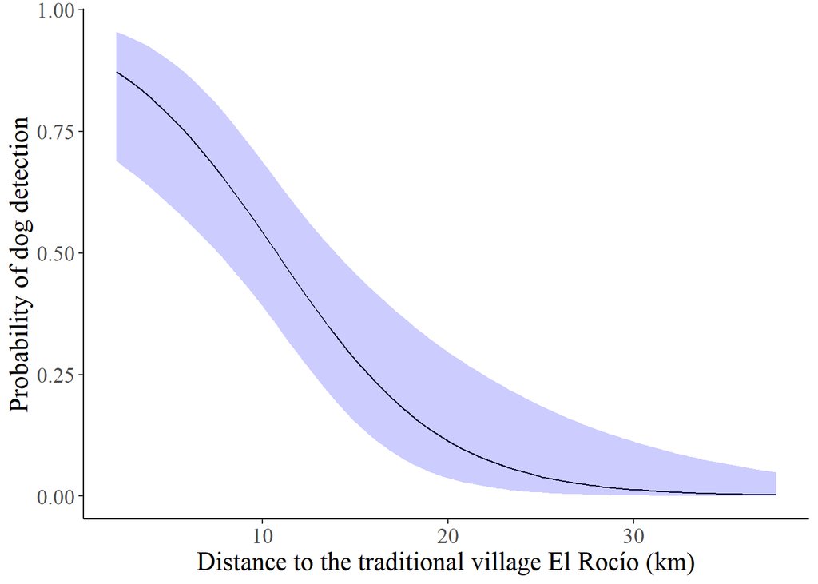

Figure 1. Change in the probability of dog detection in relation to the distance to El Rocío, a traditional village neighbouring Doñana National Park. The dark line represents the mean probability, and the shaded bands indicate the 95% confidence intervals.

```r
# Create a dataset with dist_rocio values
dist_values <- seq(min(dogs$dist_rocio), max(dogs$dist_rocio), length.out = 100)

# Predict probabilities and confidence intervals using the model
predicted <- predict(dist_rocio, newdata = data.frame(
  dist_rocio = dist_values
), type = "link", se.fit = TRUE)

# Transform predictions from log-odds to probabilities
predicted_probs <- plogis(predicted$fit)

# Create a dataframe with distance values, predicted probabilities, and confidence intervals
data_for_plot <- data.frame(
  dist_rocio = dist_values,
  P_dog = predicted_probs,
  Lower_CI = plogis(
    predicted$fit - 1.96 * predicted$se.fit
  ),  # Lower limit of confidence interval
  Upper_CI = plogis(
    predicted$fit + 1.96 * predicted$se.fit
  )  # Upper limit of confidence interval
)

# Create the plot
detection_plot <- ggplot(data_for_plot,
                         aes(x = dist_rocio,
                             y = P_dog)) +
  geom_line() +
  geom_ribbon(aes(ymin = Lower_CI,
                  ymax = Upper_CI),
              fill = "blue",
              alpha = 0.2) +
  labs(x = "Distance to the traditional village El Rocío (km)",
       y = "Probability of dog detection") +
  theme(axis.text = element_text(family = "serif",
                                 size = 13),
        axis.title = element_text(family = "serif",
                                  size = 16),
        axis.line = element_line(colour = "Black"),
        panel.background = element_rect(fill = "white"))

detection_plot
```

## Temporal variation

The temporal distribution of dogs’ detection events was quite irregular over the study period (**Figure 2**). The highest number of detections was recorded in 2022 winter after the increasing in the number of cameras (from 35 to 60) occurred in june 2022.

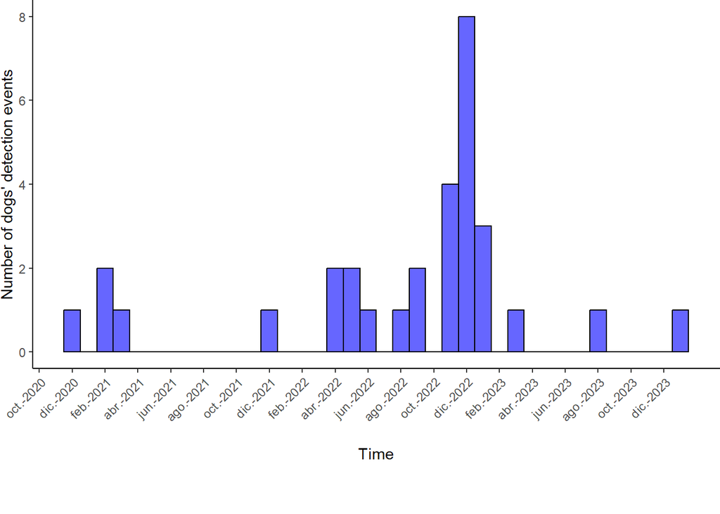

Figure 2. Temporal distribution of dogs’ detection events in Doñana National Park.

```r
# Time as a posixct object
all_data$date_time <- as.POSIXct(all_data$date_time, format = "%d/%m/%Y %H:%M", tz = "UTC")

# Take the rows with dogs presence
presence_dogs <- all_data[all_data$presence == "yes",]

# This is to see the variation of the records over time
presence_dogs$months_since_start <- as.numeric(difftime(presence_dogs$date_time, as.POSIXct("2020-10-01"), units = "days")) / (365.25 / 12)

# Filter out missing or infinite values in 'months_since_start'
filtered_dogs <- presence_dogs[is.finite(presence_dogs$months_since_start),]

# Convert the maximum date to a "Date" object
max_date <- as.Date(max(filtered_dogs$date_time))

# Create an empty data frame for custom axis labels
axis_labels <- data.frame(
  months_since_start = seq(0, max(filtered_dogs$months_since_start), by = 2),
  custom_labels = format(seq(as.Date("2020-10-01"), max_date, by = "2 months"), "%b-%Y")
)

# Create a histogram of 'months_since_start' and use custom axis labels
ggplot(filtered_dogs, aes(x = months_since_start)) +
  geom_histogram(binwidth = 1, fill = "blue", color = "black", alpha = 0.6) +
  scale_x_continuous(
    breaks = axis_labels$months_since_start,
    labels = axis_labels$custom_labels,
    name = "Time"
  ) +
  labs(y = "Number of dogs' detection events")+
  theme_classic()+
  theme(
    axis.text.x = element_text(angle = 45, vjust = 1, hjust = 1),
    axis.title.x = element_text(vjust = -5),  # Adjust the vjust value as needed
    plot.margin = margin(b = 50)
  )
```

## Controlled temporal variation

As the total number of active cameras was not the same throughout the study period, we controlled the number of dog detections according to the period of camera activity.

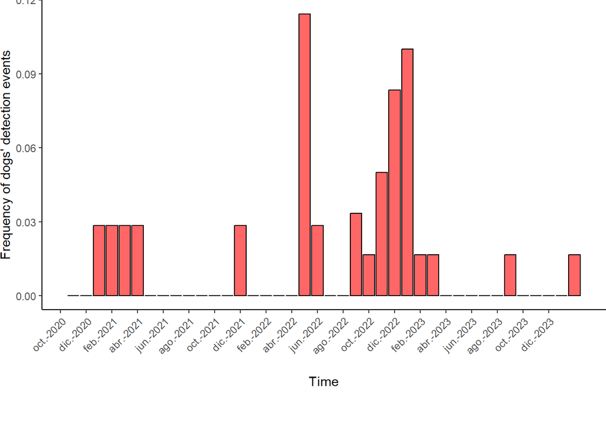

Figure 3. Temporal distribution of frequency dogs’ detection events over the study period.

```r
# Step 1: Generate a sequence of dates representing each month in the study period
study_period <- seq(as.Date("2020-10-01"), as.Date("2024-01-19"), by = "1 month")

# Step 2: Count the number of records in dogs1$date_time that fall within each month
event_counts <- presence_dogs %>%
mutate(month_year = format(as.Date(date_time), "%Y-%m")) %>%
group_by(month_year) %>%
summarize(event_freq = n())

# Step 3: Create a dataset with the month and the corresponding count
final_dataset <- data.frame(date_time = study_period)

# Modify the format of date_time to match month_year
final_dataset$month_year <- format(final_dataset$date_time, "%Y-%m")

# Left join event_counts and update event_freq to 0 if there are NA values
final_dataset <- merge(final_dataset,event_counts, by.x = "month_year", by.y = "month_year", all.x = TRUE, all.y = TRUE)
final_dataset[is.na(final_dataset)] <- 0

final_dataset <- final_dataset %>%
  mutate(
    event_freq = ifelse(event_freq == 0, 0,
                        ifelse(date_time < as.Date("2022-06-10"), event_freq/35, event_freq/60))
)

# Adding a variable which is the number of months elapsed from the start of the study period
final_dataset$months_since_start<- 1:nrow(final_dataset)

# And now a simple bar graph showing the temporal variation in the number of detections controlling for the number of available cameras
ggplot(final_dataset, aes(x = months_since_start, y = event_freq)) +
  geom_bar(stat = "identity", fill = "red", color = "black", alpha = 0.6) +
  labs(x = "Months Since Start", y = "Event Frequency") +
  scale_x_continuous(
    breaks = axis_labels$months_since_start,
    labels = axis_labels$custom_labels,
    name = "Time"
  ) +
  labs(y = "Frequency of dogs' detection events")+
 theme_classic()+
  theme(
    axis.text.x = element_text(angle = 45, vjust = 1, hjust = 1),
    axis.title.x = element_text(vjust = -5),  # Adjust the vjust value as needed
    plot.margin = margin(b = 50)
 )
```

## Activity pattern

We want to investigate the diel activity pattern of dogs presents in Doñana National Park. As the daylight hours vary considerably throughout the year in the study area, we applied a double anchor transformation to our detections, thus to link the activity to average sunrise and sunset times. We plot the activity using nonparametric kernel density plots.

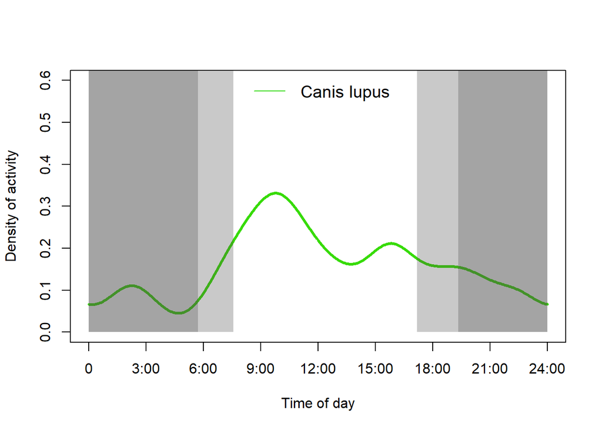

```r
# Apply the double-anchor transformation to average sunrise and sunset times
activity_dogs <- solartime(presence_dogs$date_time,
                            lat = 36.96693,
                            lon = -6.46713,
                            tz = 1,
                            format = "%Y-%m-%d %H:%M:%S")

# Take the radian solar time data anchored to average sun rise and sun set times
activity_dogs <- presence_dogs %>%
  mutate(solar = activity_dogs$solar)

# Fit circular kernel density to average-anchored times
fit_canis <- fitact(activity_dogs$solar, sample = "data")

# Create the x axis for an activity centered at day
hours_in_radians_day <- c(0, 3, 6, 9, 12, 15, 18, 21, 24) * (pi / 12)
draw_day_xaxis <- function () {
  axis(1, at = hours_in_radians_day,
       labels =c("0", "3:00","6:00","9:00", "12:00", "15:00","18:00", "21:00","24:00"),
       tick = TRUE,
       las=1)
}

# Extract the minimum and maximum times of sunrise and sunset for represent the night length
max_sunrise <-max(activity_dogs$time_sunrise[activity_dogs$season =="summer" |
                                                activity_dogs$season =="autumn"])
min_sunrise <-min(activity_dogs$time_sunrise[activity_dogs$season =="summer" |
                                                activity_dogs$season =="autumn"])
max_sunset<-max(activity_dogs$time_sunset[activity_dogs$season =="summer" |
                                             activity_dogs$season =="autumn"])
min_sunset<-min(activity_dogs$time_sunset[activity_dogs$season =="summer" |
                                             activity_dogs$season =="autumn"])

# Create a function to draw polygons representing the variation of daylight hours throughout the year

draw_day_polygons <- function() {
  polygon(x = c(0,max_sunrise, max_sunrise,0),
          y = c(0,0,10,10),
          col = rgb(0.3, 0.3, 0.3, 0.3),
          border = NA)
  polygon(x = c(0,min_sunrise, min_sunrise,0),
          y = c(0,0,10,10),
          col = rgb(0.3, 0.3, 0.3, 0.3),
          border = NA)
  polygon(x = c(min_sunset, (2*pi),(2*pi), min_sunset),
          y = c(0,0,10,10),
          col = rgb(0.3, 0.3, 0.3, 0.3),
          border = NA)
  polygon(x = c(max_sunset, (2*pi),(2*pi),
                max_sunset),
          y = c(0,0,10,10),
          col = rgb(0.3, 0.3, 0.3, 0.3),
          border=NA)
  box()
}

# Create the plot
plot(fit_canis, centre = "day", add = FALSE, xunit="radians", yunit="density",
     ylim=c(0,0.6), ylab="Density of activity", xlab="Time of day",
     tline = list(col = "#37DB04", lwd = 3),
     dline = list(col = "transparent"),
     cline = list(col = "transparent"),
     xaxis=list(xaxt="n"))

# Plot the x axis centered at day
draw_day_xaxis()

# Plot the boxes
draw_day_polygons()

# Plot the legend
legend("top", c("Canis lupus"), col = c("#37DB04"),
       box.col = "transparent", bg = "transparent", cex = 1.2, lty = 1)
```